# Data Visualisation - Customer Behaviour in Telecom

Our Data Vision

2025-07-25

In this project, we explore a Telco customer dataset with the goal of uncovering patterns and factors associated with customer churn. The dataset includes various demographic and service-related variables such as:

- **Demographics**: Gender, Senior Citizen status, Partner, Dependents
- **Service Subscriptions**: Internet service, Online Security, Tech Support, Streaming services, etc.
- **Account Information**: Contract type, Payment method, Tenure, Monthly and Total charges
- **Churn**: Whether the customer has left the company

The analysis begins with data cleaning and exploration, followed by visualizations to explore 5 research questions:

1. **How do customer demographics and contract types influence spending, and does this vary by churn behavior?**  
   This question explores whether different groups of customers—based on gender, age, and family status—spend differently, and how contract length plays a role, especially when comparing churned and non-churned customers.
2. **How does customer loyalty (tenure) vary across contract and internet service types, and how does this relate to churn?**  
   Here, we examine how long customers tend to stay based on the type of contract and internet service they use, and whether that influences their likelihood of leaving.
3. **Does having OnlineSecurity and TechSupport affect how long customers stay and how much they spend? And does this effect change depending on the type of contract they have?**  
   This focuses on whether access to key support services encourages customers to stay longer or spend more, and whether this relationship is moderated by the type of contract (month-to-month, one-year, two-year).
4. **What are the primary factors (e.g., combinations of services) that contribute most to high MonthlyCharges, and how do these factors relate to tenure and Churn behavior? Can we identify “premium” customer segments and their churn characteristics?**  
   We investigate service bundling patterns (e.g., streaming, security, support services) to see if certain combinations correlate with higher bills and longer/shorter customer lifespans.
5. **Can we identify distinct customer segments based on service usage patterns, and how do these segments differ in churn, loyalty, and spending?**  
   Finally, we aim to use clustering or visual summaries to detect meaningful customer segments and compare their behavior in terms of retention and value to the company.

```r
install.packages("plotly", repos = "https://cloud.r-project.org")
```

### Libraries

```r
library(ggplot2)
library(dplyr)
library(stringr)
library(plotly)
library(scales)
library(cluster)
library(caret)
library(tidyr)
```

### Data Preprocessing

We first perform data pre-processing steps to clean the data:

```r
data_tele <- read.csv("cleaned_customer_data.csv")
str(data_tele)
```

```
## 'data.frame':    7032 obs. of  21 variables:
##  $ customerID      : chr  "7590-VHVEG" "5575-GNVDE" "3668-QPYBK" "7795-CFOCW" ...
##  $ gender          : chr  "Female" "Male" "Male" "Male" ...
##  $ SeniorCitizen   : chr  "No" "No" "No" "No" ...
##  $ Partner         : chr  "Yes" "No" "No" "No" ...
##  $ Dependents      : chr  "No" "No" "No" "No" ...
##  $ tenure          : int  1 34 2 45 2 8 22 10 28 62 ...
##  $ PhoneService    : chr  "No" "Yes" "Yes" "No" ...
##  $ MultipleLines   : chr  "No phone service" "No" "No" "No phone service" ...
##  $ InternetService : chr  "DSL" "DSL" "DSL" "DSL" ...
##  $ OnlineSecurity  : chr  "No" "Yes" "Yes" "Yes" ...
##  $ OnlineBackup    : chr  "Yes" "No" "Yes" "No" ...
##  $ DeviceProtection: chr  "No" "Yes" "No" "Yes" ...
##  $ TechSupport     : chr  "No" "No" "No" "Yes" ...
##  $ StreamingTV     : chr  "No" "No" "No" "No" ...
##  $ StreamingMovies : chr  "No" "No" "No" "No" ...
##  $ Contract        : chr  "Month-to-month" "One year" "Month-to-month" "One year" ...
##  $ PaperlessBilling: chr  "Yes" "No" "Yes" "No" ...
##  $ PaymentMethod   : chr  "Electronic check" "Mailed check" "Mailed check" "Bank transfer (automatic)" ...
##  $ MonthlyCharges  : num  29.9 57 53.9 42.3 70.7 ...
##  $ TotalCharges    : num  29.9 1889.5 108.2 1840.8 151.7 ...
##  $ Churn           : chr  "No" "No" "Yes" "No" ...
```

```r
summary(data_tele)
```

```
##   customerID           gender          SeniorCitizen        Partner
##  Length:7032        Length:7032        Length:7032        Length:7032
##  Class :character   Class :character   Class :character   Class :character
##  Mode  :character   Mode  :character   Mode  :character   Mode  :character
##
##
##
##   Dependents            tenure      PhoneService       MultipleLines
##  Length:7032        Min.   : 1.00   Length:7032        Length:7032
##  Class :character   1st Qu.: 9.00   Class :character   Class :character
##  Mode  :character   Median :29.00   Mode  :character   Mode  :character
##                     Mean   :32.42
##                     3rd Qu.:55.00
##                     Max.   :72.00
##  InternetService    OnlineSecurity     OnlineBackup       DeviceProtection
##  Length:7032        Length:7032        Length:7032        Length:7032
##  Class :character   Class :character   Class :character   Class :character
##  Mode  :character   Mode  :character   Mode  :character   Mode  :character
##
##
##
##  TechSupport        StreamingTV        StreamingMovies      Contract
##  Length:7032        Length:7032        Length:7032        Length:7032
##  Class :character   Class :character   Class :character   Class :character
##  Mode  :character   Mode  :character   Mode  :character   Mode  :character
##
##
##
##  PaperlessBilling   PaymentMethod      MonthlyCharges    TotalCharges
##  Length:7032        Length:7032        Min.   : 18.25   Min.   :  18.8
##  Class :character   Class :character   1st Qu.: 35.59   1st Qu.: 401.4
##  Mode  :character   Mode  :character   Median : 70.35   Median :1397.5
##                                        Mean   : 64.80   Mean   :2283.3
##                                        3rd Qu.: 89.86   3rd Qu.:3794.7
##                                        Max.   :118.75   Max.   :8684.8
##     Churn
##  Length:7032
##  Class :character
##  Mode  :character
##
##
##
```

```r
# only Total Charges has NA values
sum(is.na(data_tele$TotalCharges))    # only 11 values, hence we can remove them
```

```
## [1] 0
```

```r
df_clean <- data_tele[!is.na(data_tele$TotalCharges), ]

# cleaned df
colSums(is.na(df_clean))
```

```
##       customerID           gender    SeniorCitizen          Partner
##                0                0                0                0
##       Dependents           tenure     PhoneService    MultipleLines
##                0                0                0                0
##  InternetService   OnlineSecurity     OnlineBackup DeviceProtection
##                0                0                0                0
##      TechSupport      StreamingTV  StreamingMovies         Contract
##                0                0                0                0
## PaperlessBilling    PaymentMethod   MonthlyCharges     TotalCharges
##                0                0                0                0
##            Churn
##                0
```

```r
# unique values for each variable (column)
sapply(df_clean, function(col) length(unique(col)))
```

```
##       customerID           gender    SeniorCitizen          Partner
##             7032                2                1                2
##       Dependents           tenure     PhoneService    MultipleLines
##                2               72                2                3
##  InternetService   OnlineSecurity     OnlineBackup DeviceProtection
##                3                3                3                3
##      TechSupport      StreamingTV  StreamingMovies         Contract
##                3                3                3                3
## PaperlessBilling    PaymentMethod   MonthlyCharges     TotalCharges
##                2                4             1584             6530
##            Churn
##                2
```

```r
# checking for white space only fields (there are none)
sum(df_clean$TotalCharges == " ", na.rm = TRUE)
```

```
## [1] 0
```

```r
# Convert SeniorCitizen 0/1 to "No"/"Yes"
df_clean$SeniorCitizen <- ifelse(df_clean$SeniorCitizen == 1, "Yes", "No")

table(df_clean$SeniorCitizen)
```

```
##
##   No
## 7032
```

```r
# Save cleaned data frame to csv
write.csv(df_clean, "cleaned_customer_data.csv", row.names = FALSE)
```

```r
data <- read.csv("cleaned_customer_data.csv")
```

# Introductory Data Visualizations

We first try to visualize the data:

#### 1) Bar Plots for Categorical Variables

- We first plot bar plots to visualize the categorical variables:

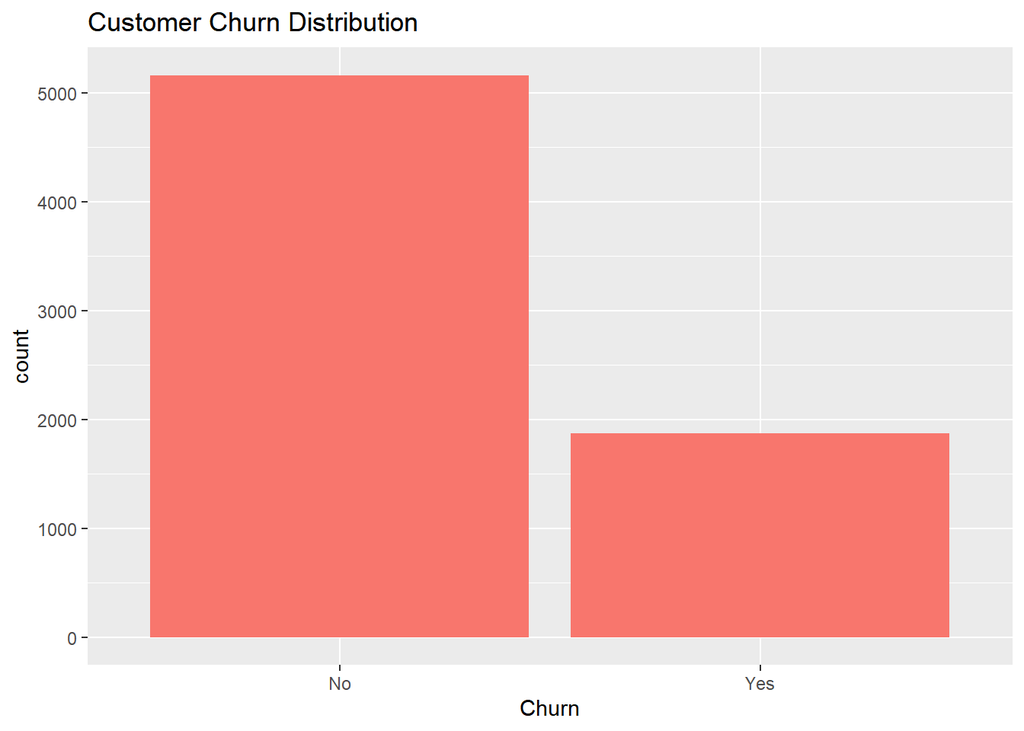

```r
# Bar plot for churn
ggplot(data, aes(x = Churn)) +
  geom_bar(fill = "#F8766D") +
  labs(title = "Customer Churn Distribution")
```

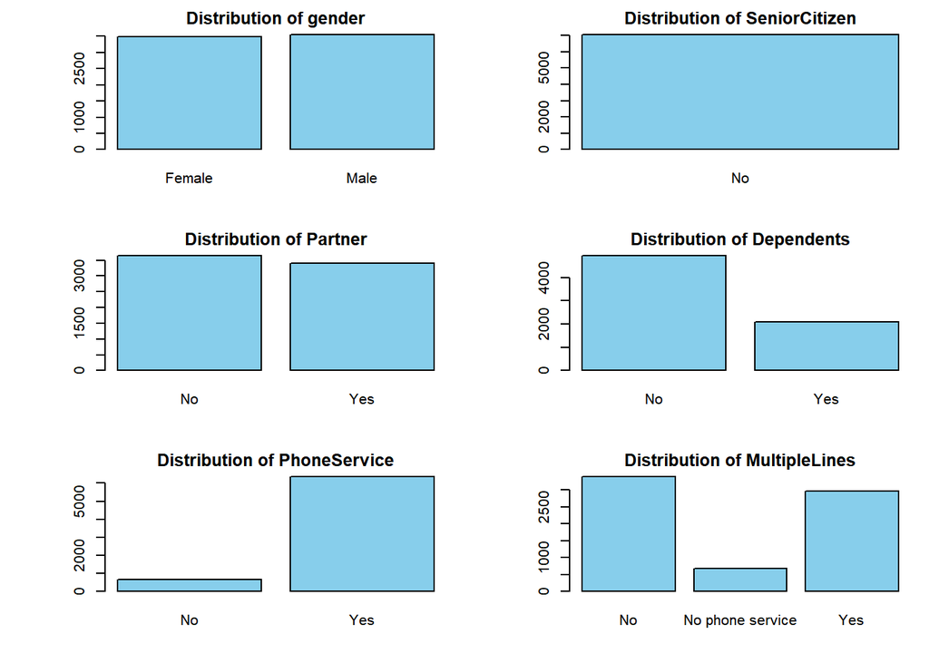

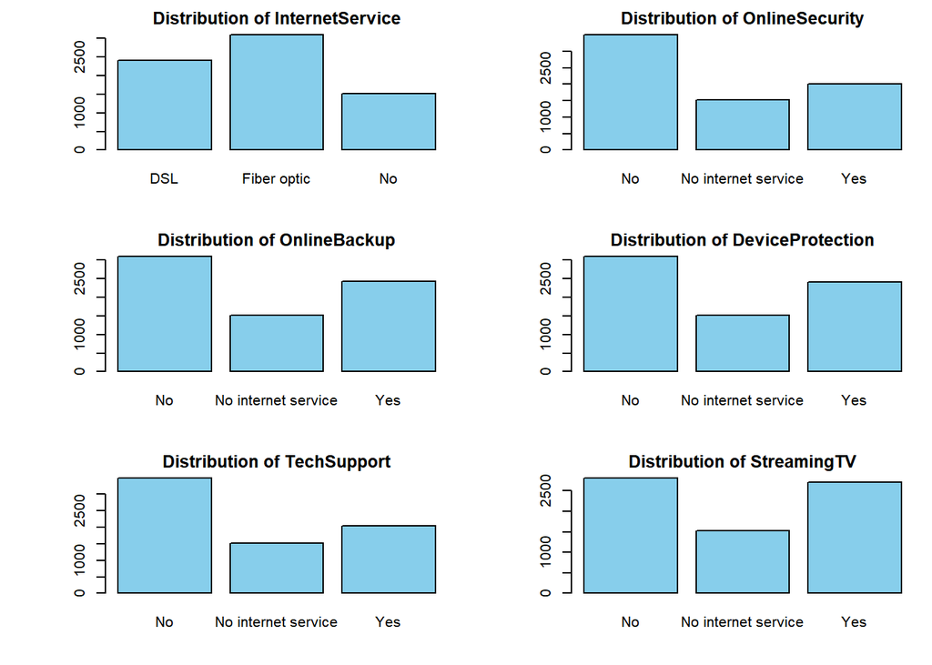

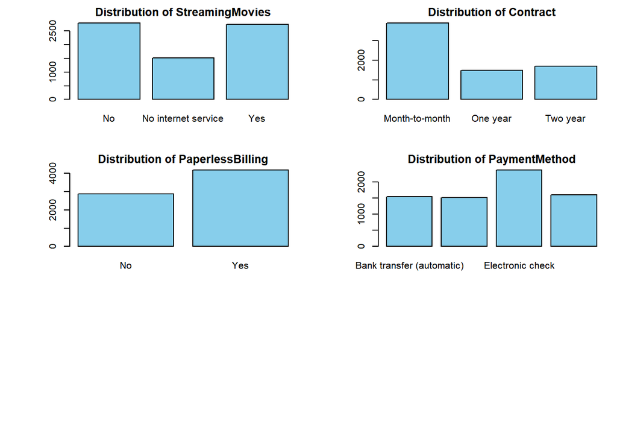

```r
cat_vars <- c("gender", "SeniorCitizen", "Partner", "Dependents", "PhoneService",
              "MultipleLines", "InternetService", "OnlineSecurity", "OnlineBackup",
              "DeviceProtection", "TechSupport", "StreamingTV", "StreamingMovies",
              "Contract", "PaperlessBilling", "PaymentMethod")

batch_size <- 6
num_batches <- ceiling(length(cat_vars) / batch_size)
num_batches <- min(num_batches, 3)  # max 3 batches

for (i in 1:num_batches) {
  start_idx <- (i - 1) * batch_size + 1
  end_idx <- min(i * batch_size, length(cat_vars))
  vars_batch <- cat_vars[start_idx:end_idx]

  par(mfrow = c(3, 2), mar = c(4, 6, 2, 1))

  for (var in vars_batch) {
    counts <- table(data[[var]])
    barplot(counts,
            main = paste("Distribution of", var),
            col = "skyblue")
  }

  par(mfrow = c(1, 1))
}
```

#### 2) Histograms for Numerical Variables

We now visualize the numeric variables using histograms, to visualize their distributions and skewness.

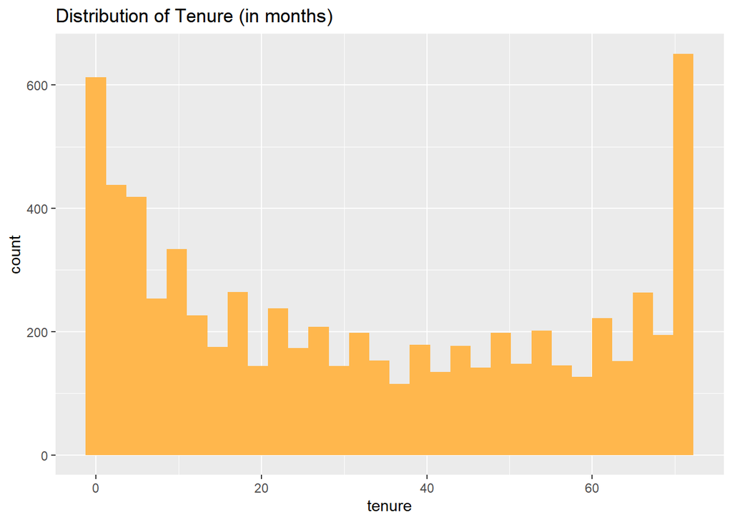

```r
ggplot(data, aes(x = tenure)) +
  geom_histogram(bins = 30, fill = "#FFB74D") +
  labs(title = "Distribution of Tenure (in months)")
```

**Observations:**

- We see a U-shaped ditribution for **tenure**:
  - First peak probably indicates customers who churn early or new customers.
  - Peak toward end indicates loyal long-term customers
  - The dip in the middle may represent those who churn gradually or drop off over time.

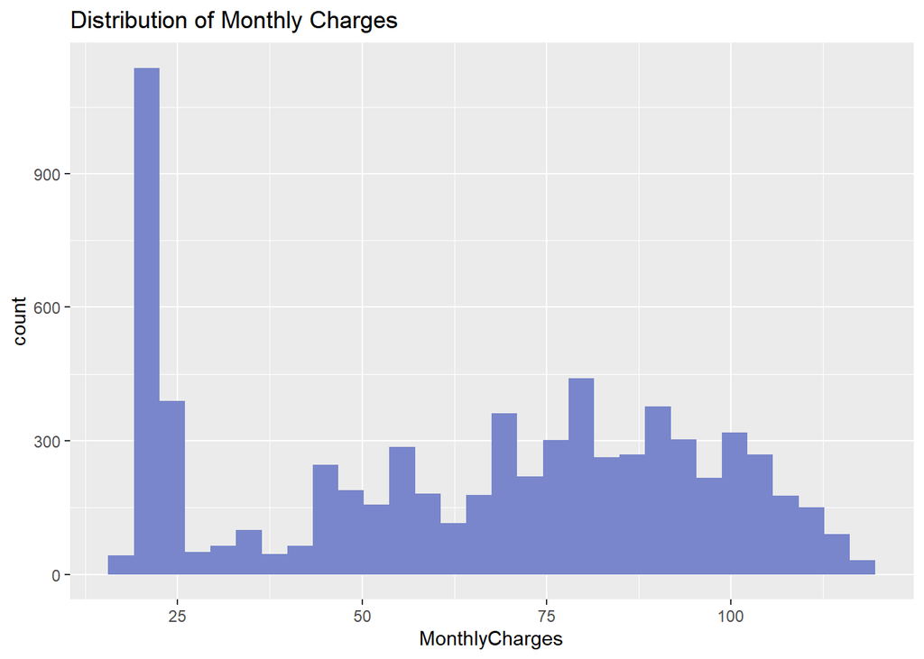

```r
ggplot(data, aes(x = MonthlyCharges)) +
  geom_histogram(bins = 30, fill = "#7986CB") +
  labs(title = "Distribution of Monthly Charges")
```

**Observations:**

- We observe that **MonthlyCharges** follows a bimodal distribution:
  - The first peak is narrower and appears around $20–$22.
  - The second peak is broader and spans roughly from $40 to $125.
- This could indicate the existence of two customer groups:
  - One customer group likely to have minimal service subscriptions (e.g., no internet or limited features)
  - And another group may be premium or bundled service users with higher monthly bills

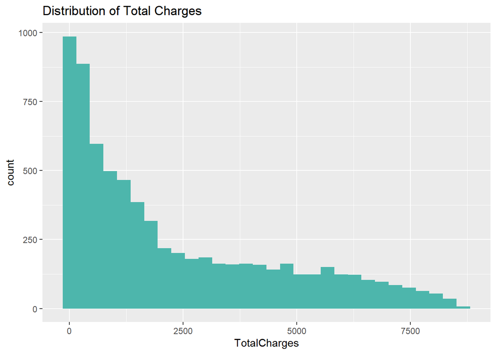

```r
ggplot(data, aes(x = TotalCharges)) +
  geom_histogram(bins = 30, fill = "#4DB6AC") +
  labs(title = "Distribution of Total Charges")
```

**Observations:**

- The histogram of **TotalCharges** shows a long tailed distribution (right-skewed)
  - **TotalCharges** is the sum of all monthly bills a customer has paid.
  - This probably indicates that that are many new customers, but with lower tenure (high frequency near 0)
    - i.e, many customers probably churn within the first few months (hence TotalCharges do not accumulate)
  - This also shows that long-term loyal customers are fewer
    - Customers who stay for longer and accumulate high TotalCharges are fewer, forming the long tail.

#### 3) Boxplots to Spot Outliers

We now plot box plots to highlight any extreme values present in any of the variables:

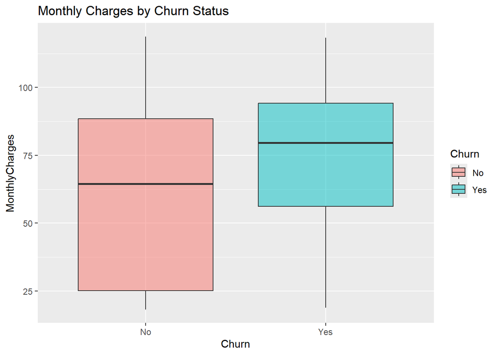

```r
ggplot(data, aes(x = Churn, y = MonthlyCharges, fill = Churn)) +
  geom_boxplot(alpha = 0.5) +
  labs(title = "Monthly Charges by Churn Status")
```

- From here we can see that:
  - Customers who did not churn had a wider spread in their monthly charges. Their charges range from low to high, and the median is relatively lower.
  - Customers who churned have higher monthly charges overall, with a higher median than the non-churned group.
    - The boxplot for churned customers is narrower, suggesting that they are more concentrated around higher charge values.
- This implies that customers paying higher monthly charges may be more likely to churn.

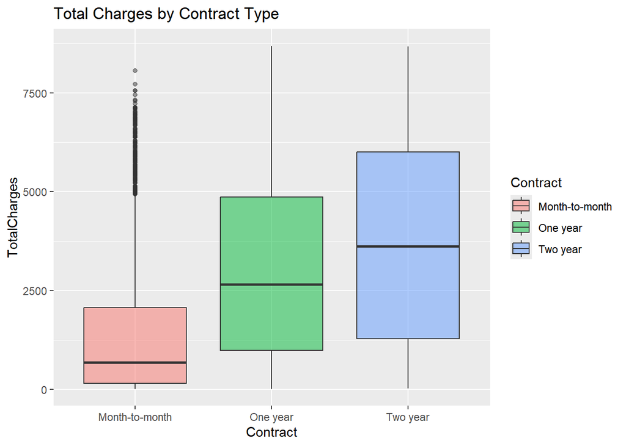

```r
ggplot(data, aes(x = Contract, y = TotalCharges, fill = Contract)) +
  geom_boxplot(alpha = 0.5) +
  labs(title = "Total Charges by Contract Type")
```

- Here we see that customers with month-to-month contracts have the lowest median total charges, followed by one year, then two year contract types.
- We can see many outliers on the high end in the month-to-month plan:
  - This could be because they have been with the company for a long time (long tenure), so even if they pay monthly, total charges add up.
  - Or they might have high monthly charges (e.g., expensive services), so their total charges get high quickly even with fewer months.

Now we can begin with the research questions.

# Question 1:

**How do customer demographics and contract types influence spending, and does this vary by churn behavior?**

### What is needed:

- Which groups spend more money?
- Does contract type change spending a lot?
- Do customers who leave pay more or less compared to those who stay?

```r
telco <- data

# Convert TotalCharges to numeric
telco$TotalCharges <- as.numeric(as.character(telco$TotalCharges))
# Convert to factors
factor_cols <- c("gender", "SeniorCitizen", "Partner", "Dependents", "Contract", "Churn")
telco[factor_cols] <- lapply(telco[factor_cols], as.factor)

str(telco)
```

```
## 'data.frame':    7032 obs. of  21 variables:
##  $ customerID      : chr  "7590-VHVEG" "5575-GNVDE" "3668-QPYBK" "7795-CFOCW" ...
##  $ gender          : Factor w/ 2 levels "Female","Male": 1 2 2 2 1 1 2 1 1 2 ...
##  $ SeniorCitizen   : Factor w/ 1 level "No": 1 1 1 1 1 1 1 1 1 1 ...
##  $ Partner         : Factor w/ 2 levels "No","Yes": 2 1 1 1 1 1 1 1 2 1 ...
##  $ Dependents      : Factor w/ 2 levels "No","Yes": 1 1 1 1 1 1 2 1 1 2 ...
##  $ tenure          : int  1 34 2 45 2 8 22 10 28 62 ...
##  $ PhoneService    : chr  "No" "Yes" "Yes" "No" ...
##  $ MultipleLines   : chr  "No phone service" "No" "No" "No phone service" ...
##  $ InternetService : chr  "DSL" "DSL" "DSL" "DSL" ...
##  $ OnlineSecurity  : chr  "No" "Yes" "Yes" "Yes" ...
##  $ OnlineBackup    : chr  "Yes" "No" "Yes" "No" ...
##  $ DeviceProtection: chr  "No" "Yes" "No" "Yes" ...
##  $ TechSupport     : chr  "No" "No" "No" "Yes" ...
##  $ StreamingTV     : chr  "No" "No" "No" "No" ...
##  $ StreamingMovies : chr  "No" "No" "No" "No" ...
##  $ Contract        : Factor w/ 3 levels "Month-to-month",..: 1 2 1 2 1 1 1 1 1 2 ...
##  $ PaperlessBilling: chr  "Yes" "No" "Yes" "No" ...
##  $ PaymentMethod   : chr  "Electronic check" "Mailed check" "Mailed check" "Bank transfer (automatic)" ...
##  $ MonthlyCharges  : num  29.9 57 53.9 42.3 70.7 ...
##  $ TotalCharges    : num  29.9 1889.5 108.2 1840.8 151.7 ...
##  $ Churn           : Factor w/ 2 levels "No","Yes": 1 1 2 1 2 2 1 1 2 1 ...
```

```r
summary(telco)
```

```
##   customerID           gender     SeniorCitizen Partner    Dependents
##  Length:7032        Female:3483   No:7032       No :3639   No :4933
##  Class :character   Male  :3549                 Yes:3393   Yes:2099
##  Mode  :character
##
##
##
##      tenure      PhoneService       MultipleLines      InternetService
##  Min.   : 1.00   Length:7032        Length:7032        Length:7032
##  1st Qu.: 9.00   Class :character   Class :character   Class :character
##  Median :29.00   Mode  :character   Mode  :character   Mode  :character
##  Mean   :32.42
##  3rd Qu.:55.00
##  Max.   :72.00
##  OnlineSecurity     OnlineBackup       DeviceProtection   TechSupport
##  Length:7032        Length:7032        Length:7032        Length:7032
##  Class :character   Class :character   Class :character   Class :character
##  Mode  :character   Mode  :character   Mode  :character   Mode  :character
##
##
##
##  StreamingTV        StreamingMovies              Contract    PaperlessBilling
##  Length:7032        Length:7032        Month-to-month:3875   Length:7032
##  Class :character   Class :character   One year      :1472   Class :character
##  Mode  :character   Mode  :character   Two year      :1685   Mode  :character
##
##
##
##  PaymentMethod      MonthlyCharges    TotalCharges    Churn
##  Length:7032        Min.   : 18.25   Min.   :  18.8   No :5163
##  Class :character   1st Qu.: 35.59   1st Qu.: 401.4   Yes:1869
##  Mode  :character   Median : 70.35   Median :1397.5
##                     Mean   : 64.80   Mean   :2283.3
##                     3rd Qu.: 89.86   3rd Qu.:3794.7
##                     Max.   :118.75   Max.   :8684.8
```

### Visualizations

**Plots that compare spending (MonthlyCharges & TotalCharges) across:**

- **Demographics**
- **Contract types**
- **Churn behavior**

**A. Boxplots**  
*Show distribution of spending by Contract and Churn.*

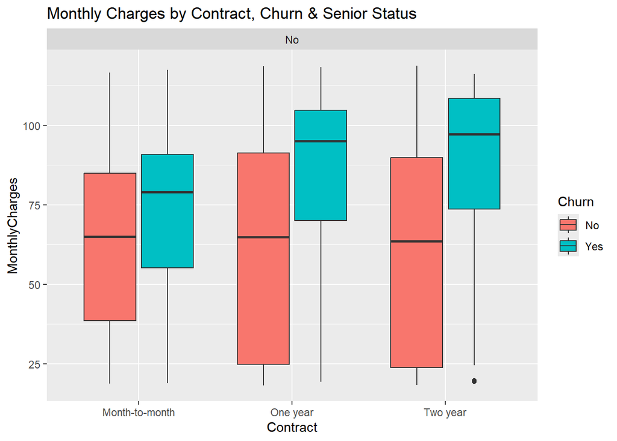

```r
ggplot(telco, aes(x = Contract, y = MonthlyCharges, fill = Churn)) +
  geom_boxplot() +
  facet_wrap(~ SeniorCitizen) +
  labs(title = "Monthly Charges by Contract, Churn & Senior Status")
```

**B. Density Plots** *how MonthlyCharges are distributed for Churn = Yes vs No..*

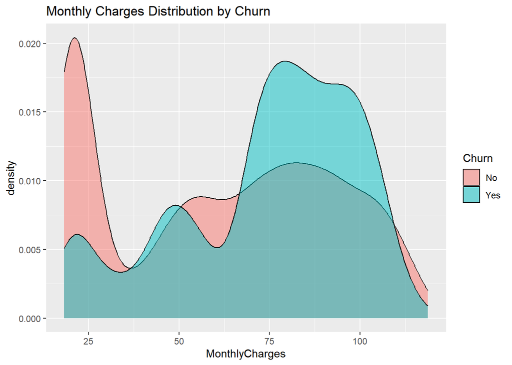

```r
ggplot(telco, aes(x = MonthlyCharges, fill = Churn)) +
  geom_density(alpha = 0.5) +
  labs(title = "Monthly Charges Distribution by Churn")
```

#### Conclusion

##### Density Plot: Monthly Charges Distribution by Churn

- The curve for **Churn = Yes** is shifted to the right, meaning customers who leave often have **higher monthly charges**.
- Customers who stayed usually have **lower and more stable charges**.

**C. Violin Plots**

Show spending spread by gender and churn.

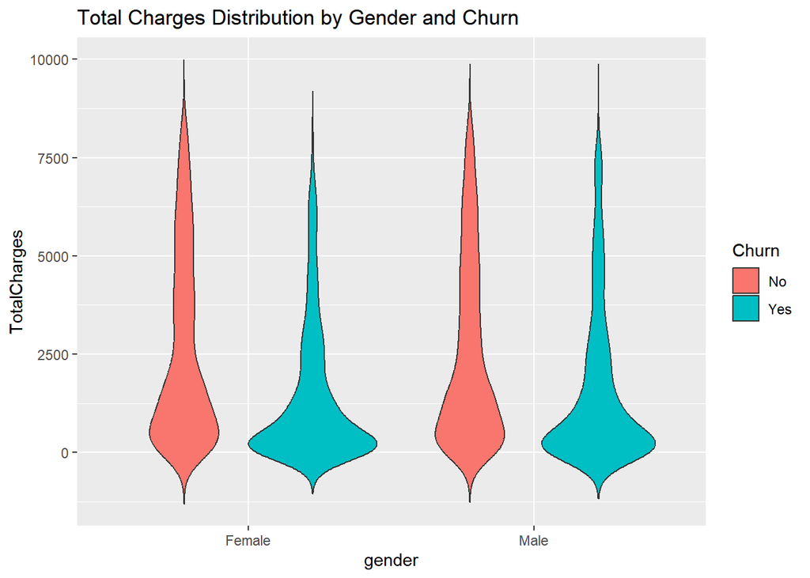

```r
ggplot(telco, aes(x = gender, y = TotalCharges, fill = Churn)) +
  geom_violin(trim = FALSE) +
  labs(title = "Total Charges Distribution by Gender and Churn")
```

#### Conclusion

##### Violin Plots: Total Charges by Gender and Churn

**Churned customers (blue) spend less** For both men and women, people who left the company had lower total charges. This likely means they didn’t stay long or didn’t use many services.

**Non-churned customers (red) spend more** Customers who stayed have higher total charges, probably because they were with the company longer and used more services.

**Gender doesn’t make much difference** Shapes of the violins are very similar between Male and Female. Gender does not significantly affect TotalCharges or churn behavior.

**D. Grouped Bar Chart** Show average MonthlyCharges by Partner/Dependents and Churn.

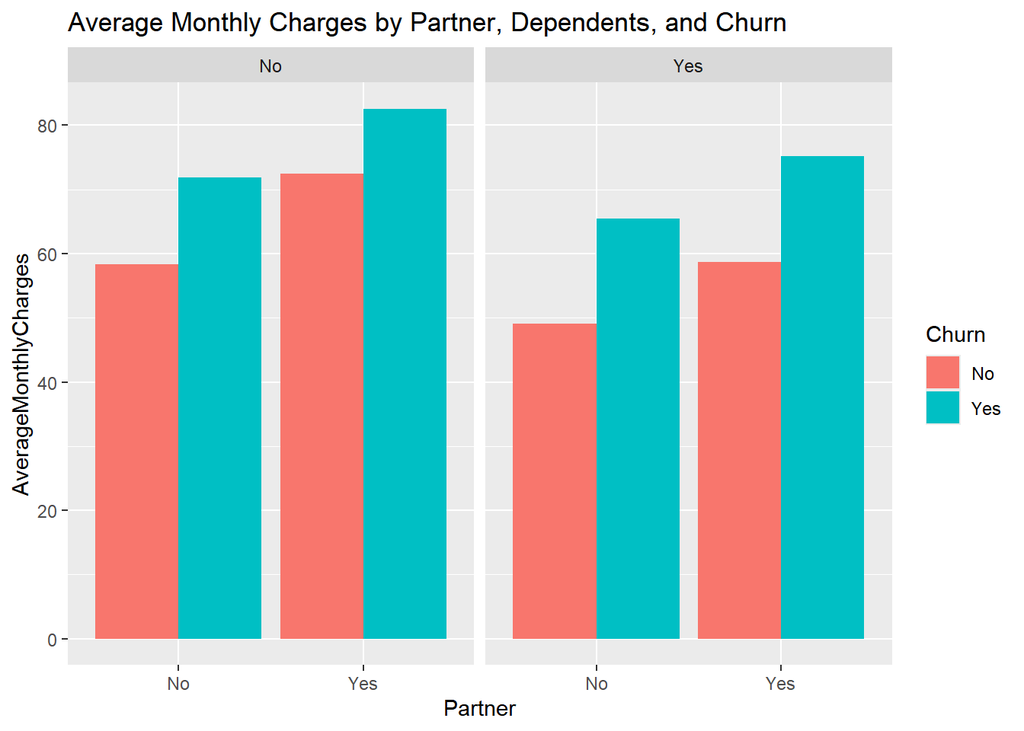

```r
avg_charges <- telco %>%
  group_by(Partner, Dependents, Churn) %>%
  summarise(AverageMonthlyCharges = mean(MonthlyCharges), .groups = "drop")

ggplot(avg_charges, aes(x = Partner, y = AverageMonthlyCharges, fill = Churn)) +
  geom_bar(stat = "identity", position = "dodge") +
  facet_wrap(~ Dependents) +
  labs(title = "Average Monthly Charges by Partner, Dependents, and Churn")
```

#### Conclusion

##### Grouped Bar Chart: Average Monthly Charges by Partner, Dependents, and Churn

Customers with a **partner** and **no dependents** leave the company and spend more money Customers **without a partner** but **with kids** (dependents) stay with the company spend less money among all groups.

# Question 2:

**How does customer loyalty (tenure) vary across contract and internet service types, and how does this relate to churn?**

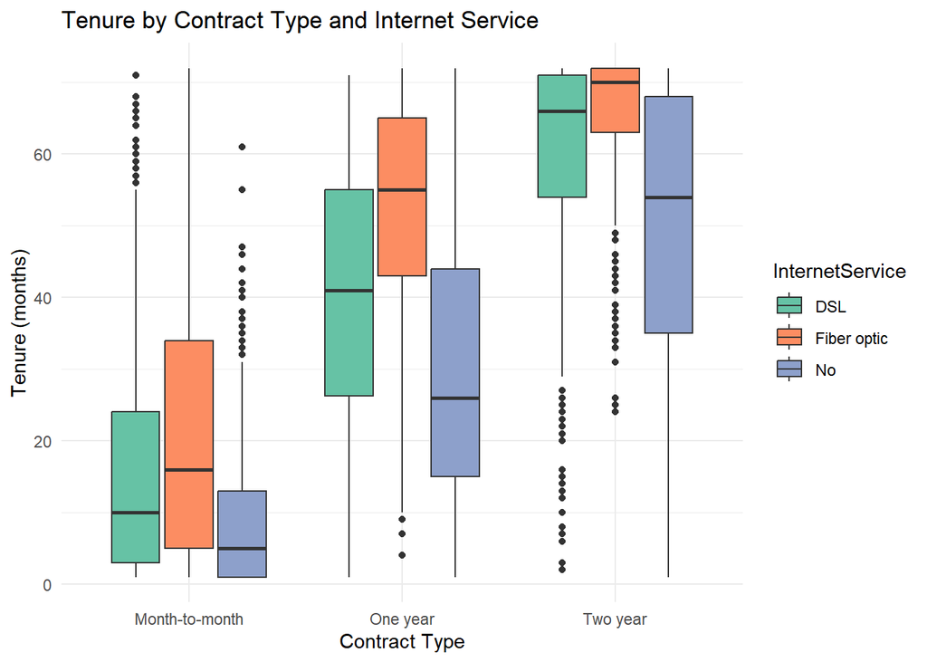

```r
# Box Plot for Tenure by Contract Type and Internet Service
ggplot(data, aes(x = Contract, y = tenure, fill = InternetService)) +
  geom_boxplot() +
  labs(title = "Tenure by Contract Type and Internet Service",
       x = "Contract Type", y = "Tenure (months)") +
  theme_minimal() +
  scale_fill_brewer(palette = "Set2")
```

#### Conclusion

**Tenure by Contract Type** 1. **Longer contracts = longer tenure:** As contract duration increases (Month-to-month → One year → Two year), median customer tenure rises significantly. 2. **Two-year contracts show highest loyalty:** These contracts have the highest median and upper quartile, indicating the strongest customer loyalty. 3. **Month-to-month contracts = low tenure:** These have the shortest tenures with low medians and wide spreads, suggesting less customer commitment.

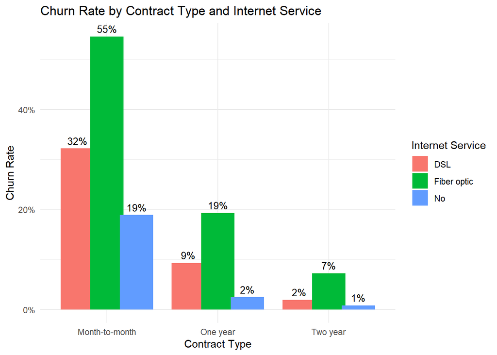

```r
# Calculate churn rate
churn_rates <- data %>%
  group_by(Contract, InternetService) %>%
  summarise(ChurnRate = mean(Churn == "Yes"), .groups = 'drop')

# Bar Plot Churn Rate by Contract Type and Internet Service
ggplot(churn_rates, aes(x = Contract, y = ChurnRate, fill = InternetService)) +
  geom_bar(stat = "identity", position = position_dodge(width = 0.8)) +
  geom_text(aes(label = scales::percent(ChurnRate, accuracy = 1)),
            position = position_dodge(width = 0.8), vjust = -0.5, size = 3.5) +
  scale_y_continuous(labels = scales::percent_format(accuracy = 1)) +
  labs(title = "Churn Rate by Contract Type and Internet Service",
       x = "Contract Type", y = "Churn Rate", fill = "Internet Service") +
  theme_minimal()
```

#### Conclusion

1. **Contract Type is Key to Churn:** Month-to-month contracts have significantly higher churn rates than one-year or two-year contracts.
2. **Two-Year Contracts Have Lowest Churn:** These show exceptionally low churn rates across all internet service types.
3. **Fiber Optic (Month-to-month) is High Risk:** Customers with Fiber Optic on a month-to-month contract have the highest churn rate at 55%.
4. **DSL Generally Lower Churn:** DSL service tends to have lower churn rates compared to Fiber Optic within the same contract type, especially for month-to-month.

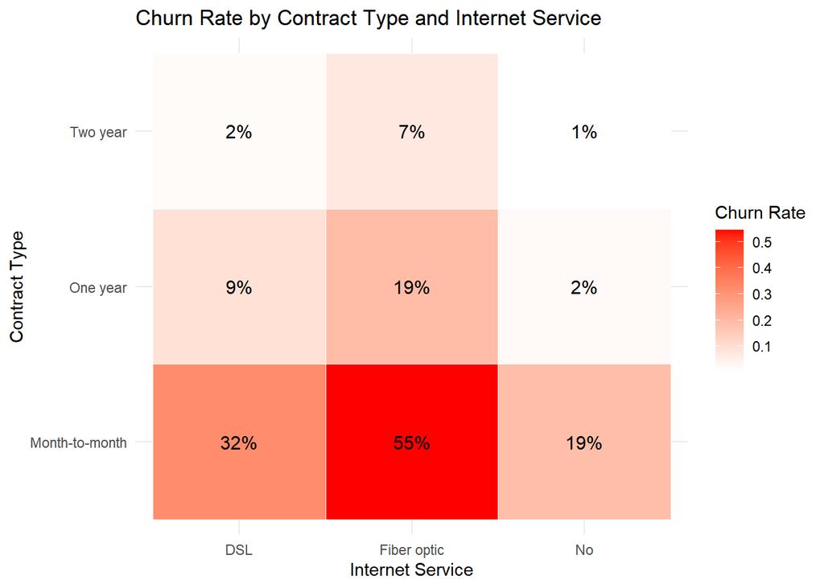

```r
#Heat Map
ggplot(churn_rates, aes(x = InternetService, y = Contract, fill = ChurnRate)) +
  geom_tile(color = "white") +
  geom_text(aes(label = scales::percent(ChurnRate, accuracy = 1)), size = 4) +
  scale_fill_gradient(low = "white", high = "red") +
  labs(title = "Churn Rate by Contract Type and Internet Service",
       x = "Internet Service", y = "Contract Type", fill = "Churn Rate") +
  theme_minimal()
```

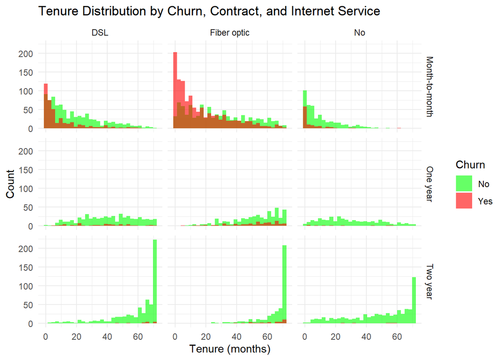

```r
#Histogram
ggplot(data, aes(x = tenure, fill = Churn)) +
  geom_histogram(position = "identity", alpha = 0.6, bins = 30) +
  facet_grid(Contract ~ InternetService) +
  labs(title = "Tenure Distribution by Churn, Contract, and Internet Service",
       x = "Tenure (months)", y = "Count") +
  scale_fill_manual(values = c("Yes" = "red", "No" = "green")) +
  theme_minimal()
```

#### Conclusion

```r
# Hypothesis Testing Framework - Model 1

#Null Hypothesis (H₀):
#Tenure, Contract Type, and Internet Service do not have any significant effect on customer churn.

#Alternative Hypothesis (H₁):
#At least one of the predictors (tenure, contract, or internet service) has a significant effect on customer churn

data$Churn <- as.factor(data$Churn)
levels(data$Churn)
```

```
## [1] "No"  "Yes"
```

```r
model <- glm(Churn ~ tenure + Contract + InternetService, data = data, family = "binomial")
summary(model)
```

```
##
## Call:
## glm(formula = Churn ~ tenure + Contract + InternetService, family = "binomial",
##     data = data)
##
## Coefficients:
##                            Estimate Std. Error z value Pr(>|z|)
## (Intercept)                -0.30682    0.06294  -4.875 1.09e-06 ***
## tenure                     -0.03139    0.00194 -16.180  < 2e-16 ***
## ContractOne year           -0.84633    0.10216  -8.284  < 2e-16 ***
## ContractTwo year           -1.67476    0.16880  -9.921  < 2e-16 ***
## InternetServiceFiber optic  1.19854    0.07248  16.536  < 2e-16 ***
## InternetServiceNo          -1.04584    0.11736  -8.911  < 2e-16 ***
## ---
## Signif. codes:  0 '***' 0.001 '**' 0.01 '*' 0.05 '.' 0.1 ' ' 1
##
## (Dispersion parameter for binomial family taken to be 1)
##
##     Null deviance: 8143.4  on 7031  degrees of freedom
## Residual deviance: 6064.1  on 7026  degrees of freedom
## AIC: 6076.1
##
## Number of Fisher Scoring iterations: 6
```

#### Conclusion

1. **Tenure Effect**

The longer a customer stays (higher tenure), the less likely they are to churn.Each additional month reduces the log-odds of churn by 0.031.

2. **Contract Type Effect**

Customers with 1-year contracts are less likely to churn than those with month-to-month plans.*

Customers with 2-year contracts are even less likely to churn — showing that long-term contracts promote loyalty.*

3. **Internet Service Effect**

   Customers with Fiber Optic are more likely to churn than DSL users — possibly due to higher expectations, service disruptions, or pricing.*

   Customers with No internet are less likely to churn — likely due to lower service usage or basic plans.

### Overall Conclusion

1. **Churners mostly leave early, within the first few months.**
2. **Customers with longer tenure tend to stay and not churn.**
3. **One-year and two-year contracts significantly reduce churn compared to month-to-month plans.**
4. **Fiber optic users on month-to-month contracts have the highest churn risk.**

# Question 3:

**Does having OnlineSecurity and TechSupport affect how long customers stay and how much they spend? And does this effect change depending on the type of contract they have?**

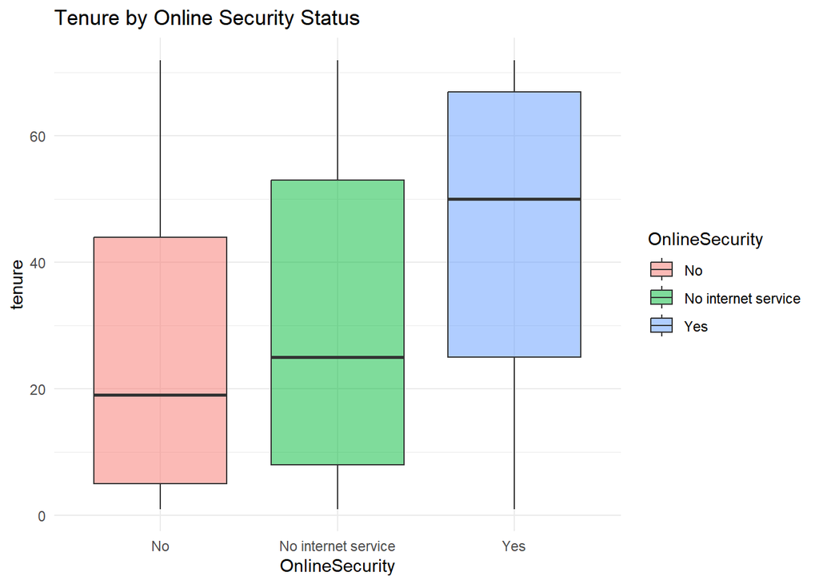

```r
# Tenure by OnlineSecurity
ggplot(data, aes(x = OnlineSecurity, y = tenure, fill = OnlineSecurity)) +
  geom_boxplot(alpha = 0.5) +
  labs(title = "Tenure by Online Security Status") +
  theme_minimal()
```

#### Conclusion

- From this graph we can see that the customers with the Online Security service had the longest tenures.
- This is followed by the customers with no internet service (probably because they have subscribed to a different service package, such as phone-only), and hence stay longer.
- The customers with the lowest tenure overall, are the ones that lack of Online Security, therefore this may be associated with shorter customer retention.

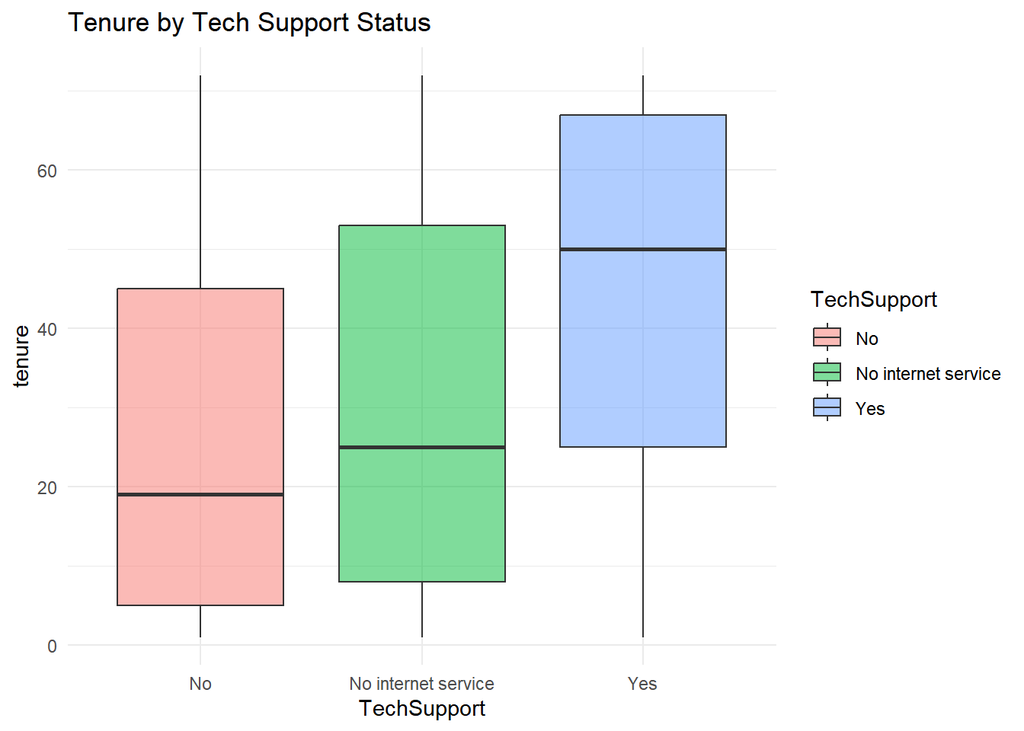

```r
# Tenure by TechSupport
ggplot(data, aes(x = TechSupport, y = tenure, fill = TechSupport)) +
  geom_boxplot(alpha = 0.5) +
  labs(title = "Tenure by Tech Support Status") +
  theme_minimal()
```

#### Conclusion

- An almost identical pattern is observed with Tech support:
  - Customers with tech support tend to stay the longest (longer retention)
  - “No internet service”- These customers again show moderately high tenure, similar to the Online Security plot. This might represent a different segment (e.g., phone service only), but still with good retention.
  - And No Tech support shows lowest tenure again
- This trend reinforces the idea that lack of support services may be associated with earlier churn or shorter contracts.

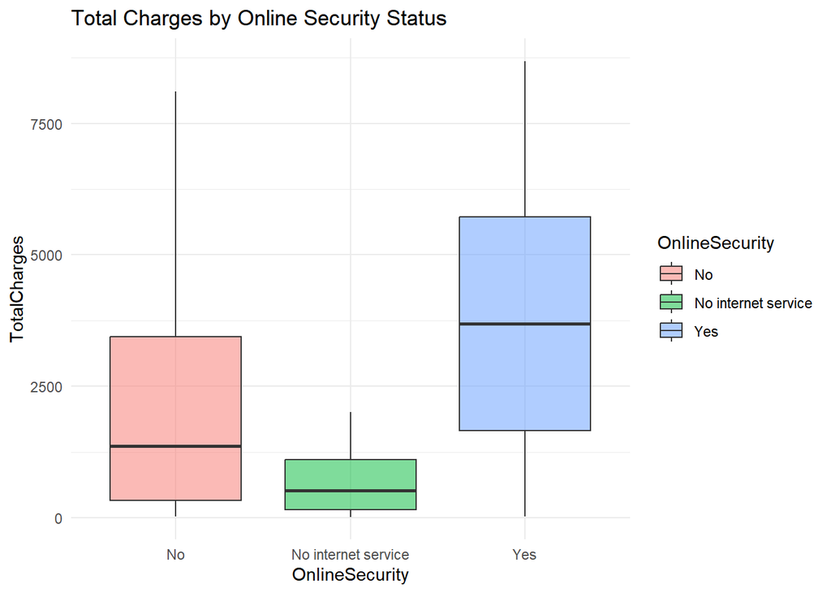

```r
# TotalCharges by OnlineSecurity
ggplot(data, aes(x = OnlineSecurity, y = TotalCharges, fill = OnlineSecurity)) +
  geom_boxplot(alpha = 0.5) +
  labs(title = "Total Charges by Online Security Status") +
  theme_minimal()
```

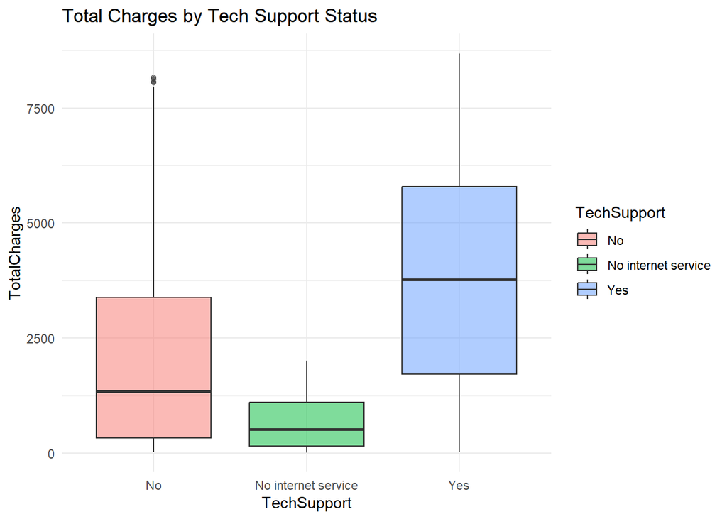

```r
# TotalCharges by TechSupport
ggplot(data, aes(x = TechSupport, y = TotalCharges, fill = TechSupport)) +
  geom_boxplot(alpha = 0.5) +
  labs(title = "Total Charges by Tech Support Status") +
  theme_minimal()
```

#### Conclusion

- We see that both the above graphs have almost identical boxplots:
  - Customers with both services (Online Security and Tech Support) accumulated higher charges, as they pay for additional costs for the extra services as expected.
  - Those with no internet service at all naturally have lower costs as they don#t have to pay for internet and extra services.
  - And those with no service charges have lower charges but more than no internet service customers as they still do pay for the internet service, but not for extra services.

### Faceted Plots (by contract type)

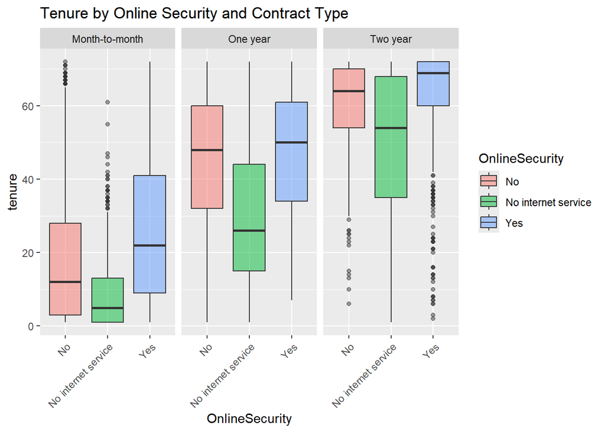

```r
# Tenure by OnlineSecurity and Contract
ggplot(data, aes(x = OnlineSecurity, y = tenure, fill = OnlineSecurity)) +
  geom_boxplot(alpha = 0.5) +
  facet_wrap(~ Contract) +
  labs(title = "Tenure by Online Security and Contract Type") +
  theme(axis.text.x = element_text(angle = 45, hjust = 1))
```

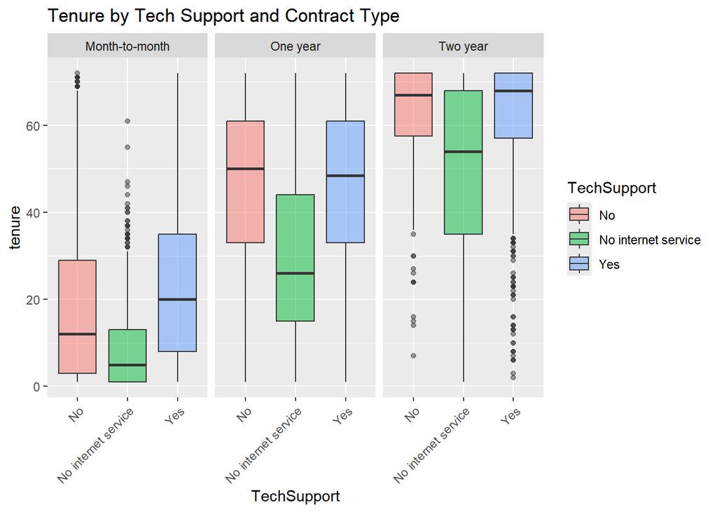

```r
# Tenure by TechSupport and Contract
ggplot(data, aes(x = TechSupport, y = tenure, fill = TechSupport)) +
  geom_boxplot(alpha = 0.5) +
  facet_wrap(~ Contract) +
  labs(title = "Tenure by Tech Support and Contract Type") +
  theme(axis.text.x = element_text(angle = 45, hjust = 1))
```

#### Conclusion

**Outliers**  
- We see many outliers, particularly in month-to-month contracts and in two year contracts:

- In two year contracts - this could suggest that some customers still terminate early, indicating variability in retention behavior even among those who committed to longer terms.
- In shorter (month-to-month) contracts - this represents the opposite case: unexpectedly long tenures despite the lack of contractual obligation. These long-tenured outliers in month-to-month contracts may reflect high satisfaction for customers

**Notable observation:**

- In the aggregated (non-faceted) box plots of tenure vs. services, it appeared that: customers with services > no internet service > customers with no services in terms of tenure.
- However, in the faceted plots (broken down by contract type), the pattern changed to: customers with services > no services > no internet service.
- This shift highlights that when we control for contract type, the impact of service usage on tenure becomes less significant.
- Therefore, contract type (month-to-month, 1-year, 2-year) is a stronger driver of tenure than the presence or absence of internet or other services.

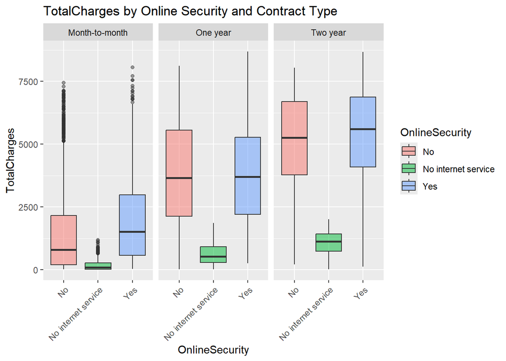

```r
# Tenure by OnlineSecurity and Contract
ggplot(data, aes(x = OnlineSecurity, y = TotalCharges, fill = OnlineSecurity)) +
  geom_boxplot(alpha = 0.5) +
  facet_wrap(~ Contract) +
  labs(title = "TotalCharges by Online Security and Contract Type") +
  theme(axis.text.x = element_text(angle = 45, hjust = 1))
```

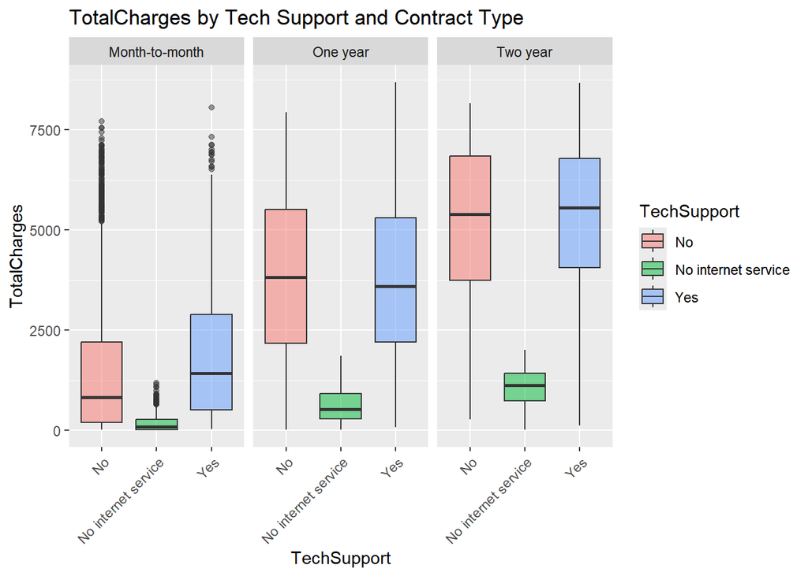

```r
# Tenure by TechSupport and Contract
ggplot(data, aes(x = TechSupport, y = TotalCharges, fill = TechSupport)) +
  geom_boxplot(alpha = 0.5) +
  facet_wrap(~ Contract) +
  labs(title = "TotalCharges by Tech Support and Contract Type") +
  theme(axis.text.x = element_text(angle = 45, hjust = 1))
```

#### Conclusion

- We see that both service (Online Security and Tech Support) plots show almost identical patterns again.
- For Total Charges the initial (aggregated) and faceted box plots show the same consistent patterns across contract types. (yes > no > no service)
  - This means that contract type does not confound the relationship between service usage and Total Charges.
- Additionally we see that:
  - For 1-year and 2-year contracts, Total Charges are almost the same for customers with and without the additional services.
  - This suggests that contract length, and not the service usage, is the primary driver of total charges in these cases.
  - For month-to-month contracts, customers with the services have slightly higher Total Charges, possibly due to longer retention.

### Combined Services and Contract Type Plot

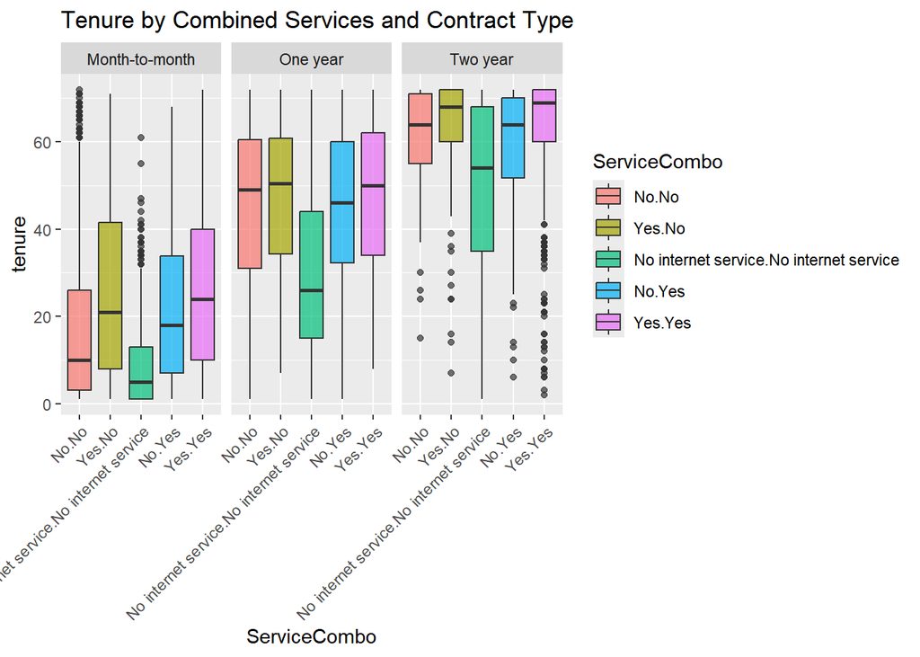

```r
data$ServiceCombo <- interaction(data$OnlineSecurity, data$TechSupport)

ggplot(data, aes(x = ServiceCombo, y = tenure, fill = ServiceCombo)) +
  geom_boxplot(alpha = 0.7) +
  facet_wrap(~ Contract) +
  labs(title = "Tenure by Combined Services and Contract Type") +
  theme(axis.text.x = element_text(angle = 45, hjust = 1))
```

#### Conclusion

- The faceted plot shows that contract type plays a dominant role in determining customer tenure.
  - In month-to-month contracts, service usage (especially presence of internet and security features) appears to influence tenure.
    - Customers with more services tend to stay longer.
  - In long-term contracts, customers stay longer regardless of service use — contract commitment outweighs service importance.

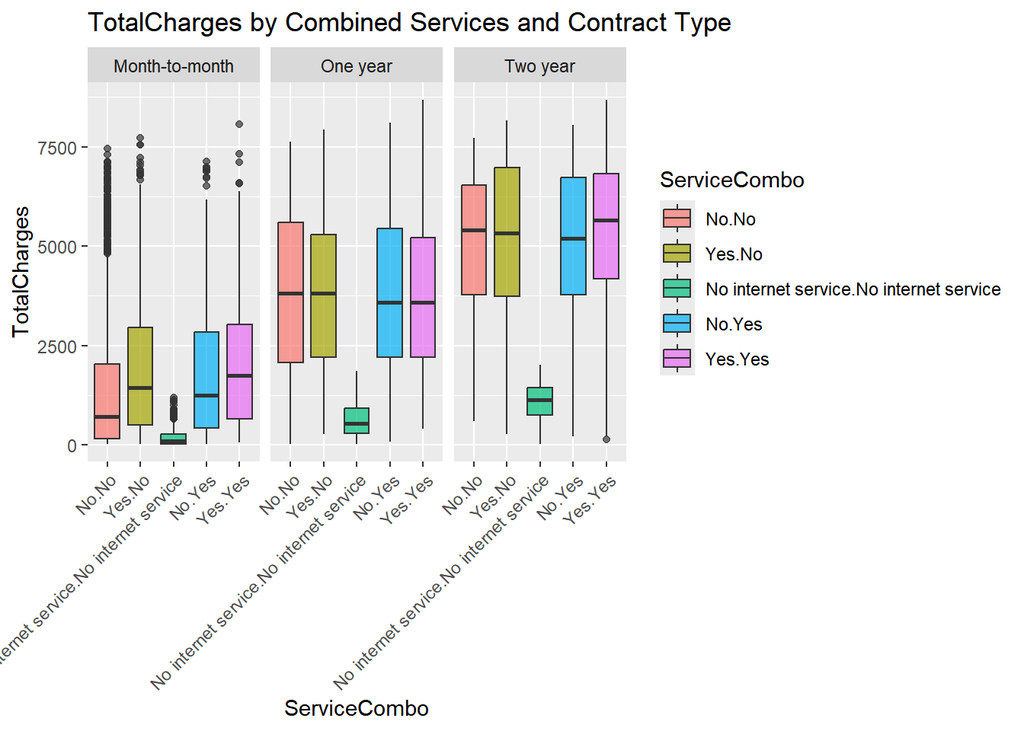

```r
ggplot(data, aes(x = ServiceCombo, y = TotalCharges, fill = ServiceCombo)) +
  geom_boxplot(alpha = 0.7) +
  facet_wrap(~ Contract) +
  labs(title = "TotalCharges by Combined Services and Contract Type") +
  theme(axis.text.x = element_text(angle = 45, hjust = 1))
```

#### Conclusion

- The consistent patterns across contract types indicate that the relationship between service usage and TotalCharges is not confounded by contract type.
- In 1-year and 2-year contracts, TotalCharges are high and similar regardless of service combination — driven mostly by contract length and tenure.
- In month-to-month contracts, service usage has a slight impact on TotalCharges, but still much less than contract duration.
- This suggests that TotalCharges is mostly impacted by contract type and time spent with the company, while the effect of additional services is relatively small.

### Overall Conclusion:

- OnlineSecurity and TechSupport slightly increase tenure and TotalCharges for month-to-month customers.
- For 1-year and 2-year contracts, these services have little to no effect — contract length drives tenure and spending.
- Contract type is the most important factor influencing both how long customers stay and how much they spend.
- The impact of services is only important in short-term contracts where customers have more flexibility to leave.

# Question 4:

**What are the primary factors (e.g., combinations of services) that contribute most to high MonthlyCharges, and how do these factors relate to tenure and Churn behavior? Can we identify “premium” customer segments and their churn characteristics?**

### What is needed:

- Which **combinations of services** lead to **high MonthlyCharges**?
- Do customers with those combinations **stay longer or churn more**?
- Can we define and understand a **“premium” segment** with high charges and churn risk?

```r
# Step 1: Find service combinations that contribute most to high MonthlyCharges

# Select service-related columns
service_cols <- c("OnlineSecurity", "OnlineBackup", "DeviceProtection",
                  "TechSupport", "StreamingTV", "StreamingMovies", "PhoneService")
data$service_count <- rowSums(data[service_cols] == "Yes")  # Number of active services
```

```r
# Replace "No internet service" and "No phone service" with "No" to simplify categories
data <- data %>%
  mutate(across(
    all_of(service_cols),
    ~ ifelse(. %in% c("No internet service", "No phone service"), "No", .)
  ))
```

```r
# Create a combined label showing all active services per customer
data$ServiceCombo <- apply(data[service_cols], 1, function(row) {
  active <- names(row)[row == "Yes"]
  if (length(active) == 0) {
    return("(No Add-ons)")
  } else {
    return(paste(active, collapse = " + "))
  }
})
```

### A. Average Monthly Charges by Service Combination

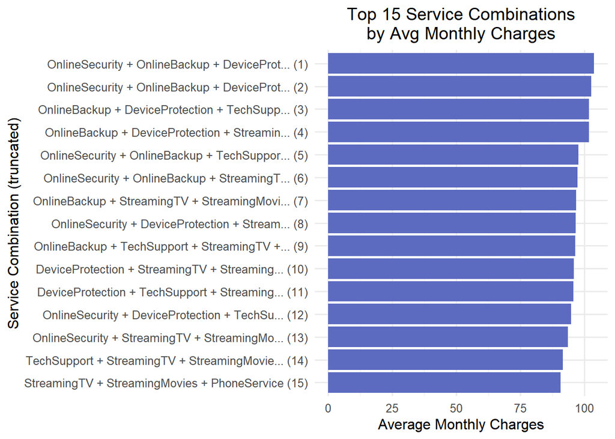

Top 15 Full Service Combinations with Avg Charges and Counts

| ServiceCombo | avg_charge | count |
| --- | --- | --- |
| OnlineSecurity + OnlineBackup + DeviceProtection + StreamingTV + StreamingMovies + PhoneService | 103.90253 | 79 |
| OnlineSecurity + OnlineBackup + DeviceProtection + TechSupport + StreamingTV + StreamingMovies + PhoneService | 102.69691 | 259 |
| OnlineBackup + DeviceProtection + TechSupport + StreamingTV + StreamingMovies + PhoneService | 101.86556 | 151 |
| OnlineBackup + DeviceProtection + StreamingTV + StreamingMovies + PhoneService | 101.78917 | 180 |
| OnlineSecurity + OnlineBackup + TechSupport + StreamingTV + StreamingMovies + PhoneService | 97.72545 | 55 |
| OnlineSecurity + OnlineBackup + StreamingTV + StreamingMovies + PhoneService | 97.45244 | 41 |
| OnlineBackup + StreamingTV + StreamingMovies + PhoneService | 96.93257 | 109 |
| OnlineSecurity + DeviceProtection + StreamingTV + StreamingMovies + PhoneService | 96.71825 | 63 |
| OnlineBackup + TechSupport + StreamingTV + StreamingMovies + PhoneService | 96.49155 | 71 |
| DeviceProtection + StreamingTV + StreamingMovies + PhoneService | 95.92259 | 166 |
| DeviceProtection + TechSupport + StreamingTV + StreamingMovies + PhoneService | 95.80755 | 106 |
| OnlineSecurity + DeviceProtection + TechSupport + StreamingTV + StreamingMovies + PhoneService | 94.86081 | 111 |
| OnlineSecurity + StreamingTV + StreamingMovies + PhoneService | 93.55755 | 53 |
| TechSupport + StreamingTV + StreamingMovies + PhoneService | 91.61439 | 66 |
| StreamingTV + StreamingMovies + PhoneService | 90.81345 | 197 |

```r
# Calculate average monthly charges and count for each service combination
combo_stats <- data %>%
  group_by(ServiceCombo) %>%
  summarise(
    avg_charge = mean(MonthlyCharges, na.rm = TRUE),
    count = n()
  ) %>%
  ungroup() %>%
  filter(count >= 10) %>%  # Filter out rare combinations
  arrange(desc(avg_charge)) %>%
  slice_max(avg_charge, n = 15)

# Reorder factor levels based on avg_charge for plotting
combo_stats <- combo_stats %>%
  mutate(ComboLabel = paste0(str_trunc(ServiceCombo, 45), " (", row_number(), ")")) %>%
  mutate(ComboLabel = factor(ComboLabel, levels = ComboLabel[order(avg_charge)]))

# Plot: Top 15 service combinations by average monthly charges
ggplot(combo_stats, aes(x = ComboLabel, y = avg_charge)) +
  geom_col(fill = "#5C6BC0") +
  coord_flip() +
  scale_y_continuous(labels = comma_format(accuracy = 1)) +
  labs(
    title = "Top 15 Service Combinations\nby Avg Monthly Charges",
    x = "Service Combination (truncated)",
    y = "Average Monthly Charges"
  ) +
  theme_minimal(base_size = 12) +
  theme(plot.title = element_text(hjust = 0.5))
```

### B. Churn Rate for Top Combinations

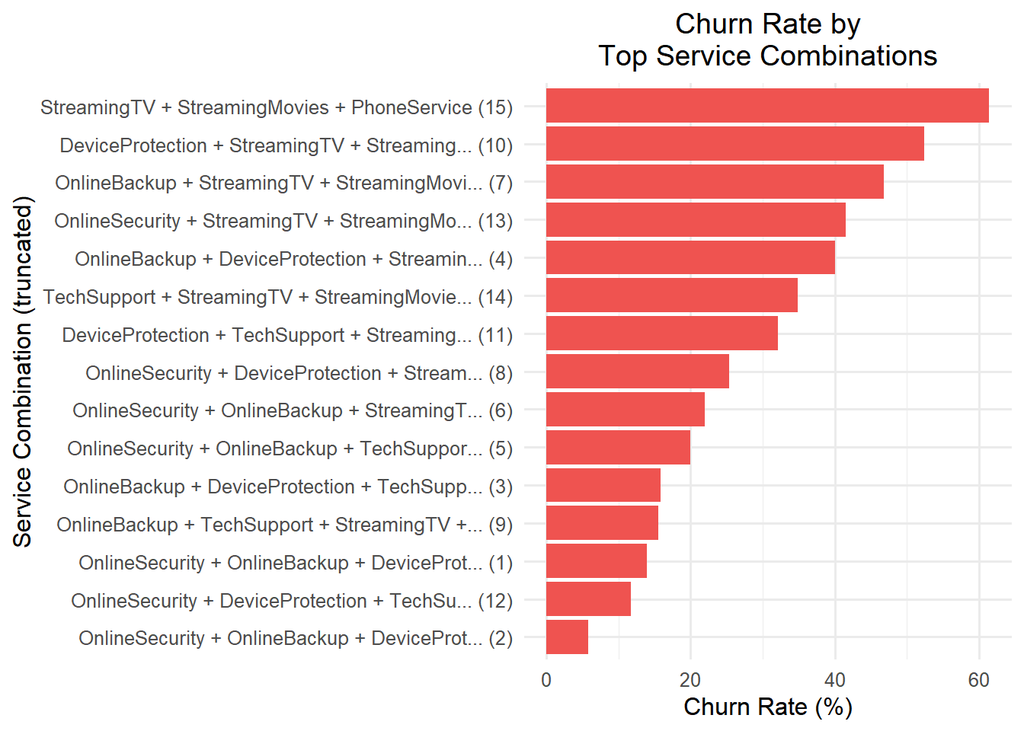

```r
# Step 1: Use top 15 combos
top_combos <- combo_stats$ServiceCombo

# Step 2: Summarize churn and tenure for those combos
combo_churn_df <- data %>%
  filter(ServiceCombo %in% top_combos) %>%
  group_by(ServiceCombo) %>%
  summarise(
    ChurnRate = mean(Churn == "Yes") * 100,
    AvgTenure = mean(tenure),
    Count = n()
  ) %>%
  ungroup()

# Step 3: Join with truncated labels
combo_churn_df <- left_join(combo_churn_df, combo_stats %>%
                               select(ServiceCombo, ComboLabel), by = "ServiceCombo")

# Step 4: Plot churn rate
ggplot(combo_churn_df, aes(x = reorder(ComboLabel, ChurnRate), y = ChurnRate)) +
  geom_col(fill = "#EF5350") +
  coord_flip() +
  labs(title = "Churn Rate by\nTop Service Combinations",
       x = "Service Combination (truncated)",
       y = "Churn Rate (%)") +
  theme_minimal(base_size = 12) +
  theme(plot.title = element_text(hjust = 0.5))
```

#### Conclusion: Churn Rate by Combo

- Some high-charge combos **also churn more frequently**.
- Heavy churn in combos with **streaming but no support services**.
- Lower churn in combos that include **TechSupport** and **OnlineSecurity**.

### C. Average Tenure by Service Combination

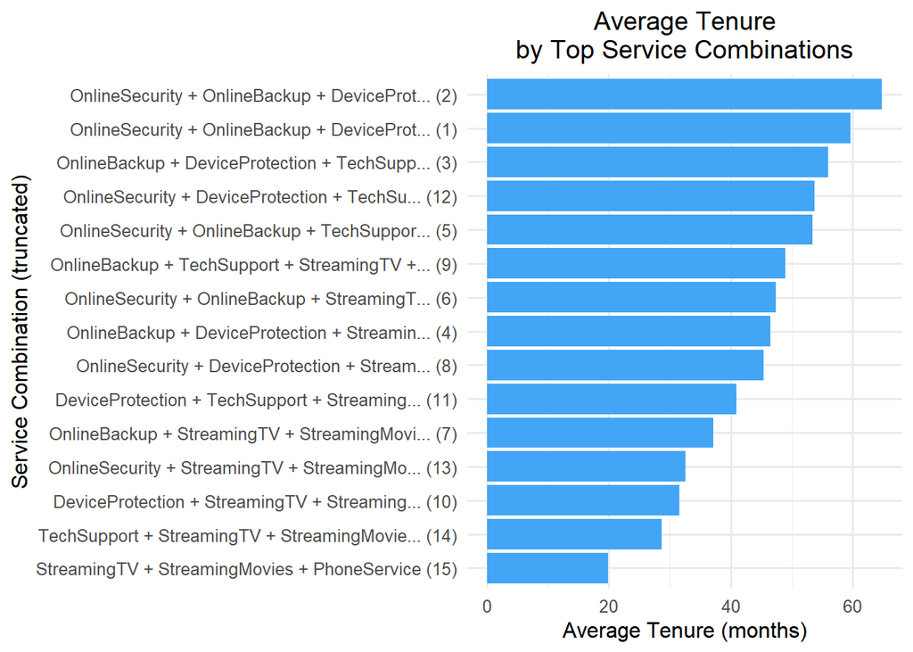

#### Conclusion: Average Tenure by Combo

Churn Rate and Avg Tenure by Top Service Combinations

| ServiceCombo | ChurnRate | AvgTenure | Count |
| --- | --- | --- | --- |
| StreamingTV + StreamingMovies + PhoneService | 61.42 | 19.89 | 197 |
| DeviceProtection + StreamingTV + StreamingMovies + PhoneService | 52.41 | 31.49 | 166 |
| OnlineBackup + StreamingTV + StreamingMovies + PhoneService | 46.79 | 37.09 | 109 |
| OnlineSecurity + StreamingTV + StreamingMovies + PhoneService | 41.51 | 32.51 | 53 |
| OnlineBackup + DeviceProtection + StreamingTV + StreamingMovies + PhoneService | 40.00 | 46.52 | 180 |
| TechSupport + StreamingTV + StreamingMovies + PhoneService | 34.85 | 28.68 | 66 |
| DeviceProtection + TechSupport + StreamingTV + StreamingMovies + PhoneService | 32.08 | 40.90 | 106 |
| OnlineSecurity + DeviceProtection + StreamingTV + StreamingMovies + PhoneService | 25.40 | 45.37 | 63 |
| OnlineSecurity + OnlineBackup + StreamingTV + StreamingMovies + PhoneService | 21.95 | 47.37 | 41 |
| OnlineSecurity + OnlineBackup + TechSupport + StreamingTV + StreamingMovies + PhoneService | 20.00 | 53.33 | 55 |
| OnlineBackup + DeviceProtection + TechSupport + StreamingTV + StreamingMovies + PhoneService | 15.89 | 55.98 | 151 |
| OnlineBackup + TechSupport + StreamingTV + StreamingMovies + PhoneService | 15.49 | 48.89 | 71 |
| OnlineSecurity + OnlineBackup + DeviceProtection + StreamingTV + StreamingMovies + PhoneService | 13.92 | 59.58 | 79 |
| OnlineSecurity + DeviceProtection + TechSupport + StreamingTV + StreamingMovies + PhoneService | 11.71 | 53.67 | 111 |
| OnlineSecurity + OnlineBackup + DeviceProtection + TechSupport + StreamingTV + StreamingMovies + PhoneService | 5.79 | 64.80 | 259 |

### D. Identify Premium Customer Segments

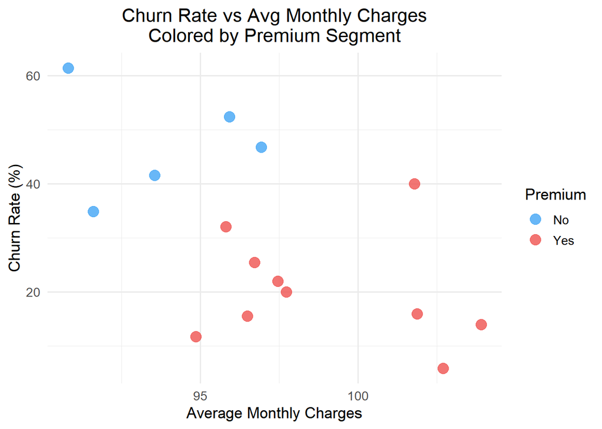

# Question 05

**Can we identify distinct customer segments based on service usage patterns, and how do these segments differ in churn, loyalty, and spending?**

- The goal is to group customers into meaningful segments based on all the services they use such as phone, internet, security, streaming, etc.
- Once we’ve grouped them (using clustering), we want to compare those groups to see:
  - Which groups have higher or lower churn rates? (Who is more likely to leave?)
  - Which groups are paying more or less each month? (Spending patterns)
  - Which groups have been with the company longer or shorter? (Customer loyalty)